# 4. Analyse Drosben survival data

Terrence M. Trinca and Joaquín de Navascués

## 4A. Setting up

### Computing tools

If you have not used R before, you are probably reading this in its HTML version and you do not know how to run an R markdown notebook. If this is the case, our recommendation is that you first install R and RStudio from [the Comprehensive R Archive Network, CRAN](https://cran.r-project.org/) and the [Posit Software, PBC](https://posit.co/download/rstudio-desktop) download sites, respectively, and follow their instructions. It just takes a couple of minutes. If you feel a bit lost, the R-ladies’ Sydney chapter has a nice [‘basic-basic’ tutorial to using RStudio](https://rladiessydney.org/courses/01-basicbasics-0).

Once you have done this, you can just double-click on the ‘Rmd’ version of this notebook to run it as you ran the Jupyter notebooks.

All the analysis examples here are just using the work of (mostly) Dr Terry M Therneau ([Survival package](https://cran.r-project.org/web/packages/survival/)) and (again, mostly) Alboukadel Kassambara ([Survminer package](https://cran.r-project.org/web/packages/survminer/))

```r
require(librarian)
librarian::shelf(
  tidyverse, readxl,
  survival, survminer, glue,
  gtsummary, kableExtra,
  ggthemes, ggtext, ggnewscale, RColorBrewer,
  grid, gridExtra, # TMT
  knitr,
  rstudioapi, # TMT
  quiet = TRUE)
knitr::opts_chunk$set(message = FALSE, warning = FALSE)
```

Some helper functions we will use later:

```r
# utility to choose more or less interactively the line styles
surv_two_var_aes <- function(fit, data,
                             hue, # one var distinguished by distinct colours
                             palette = 'Set2', # selection of Brewer colours
                             idx = c(1,2),     # by colour number within palette
                             hue_direction = c("hot2cold", "cold2hot"), # order of colours
                             shade = var2, # other var distinguished by saturation and linetype
                             darkening=FALSE,
                             linetypes = c("solid", "longdash", "dashed", "dotted")) {

  if (!is.factor(data[[hue]]))   data[[hue]]   <- factor(data[[hue]])
  if (!is.factor(data[[shade]])) data[[shade]] <- factor(data[[shade]])
  hue_levels   <- levels(data[[hue]])      # reference = first
  shade_levels <- levels(data[[shade]])
  nh <- length(hue_levels)
  ns <- length(shade_levels)

  if (length(idx) != nh)
    stop("`idx` must have one index per `hue` level (", nh, "), got ", length(idx), ".")
  if (length(palette) == 1L) palette <- rep(palette, nh)
  if (length(palette) != nh)
    stop("`palette` must be length 1 (shared) or one per `hue` level (", nh, ").")
  if (ns > length(linetypes))
    stop("`shade` has ", ns, " levels but only ", length(linetypes), " linetypes.")

  hue_direction <- match.arg(hue_direction)

  linetype_combos <- list(
    '2' = linetypes[c(1,4)],
    '3' = linetypes[c(1,3,4)],
    '4' = linetypes
  )

  ## base colours → borrow hue and value per hue level
  base_cols <- vapply(seq_len(nh),
                      function(i) brewer.pal(8, palette[i])[idx[i]], character(1))
  if (length(base_cols) != length(unique(base_cols)))
    stop("you have repeated hues - please check the `palette` and `idx` arguments")

  hsvb  <- rgb2hsv(col2rgb(base_cols))         # rows: h, s, v
  if(hue_direction=="hot2cold") {
    hsvb <- hsvb[, order(hsvb["h", ])]
    } else {
    hsvb <- hsvb[, rev(order(hsvb["h", ]))]
    }
  H_lev <- setNames(hsvb["h", ], hue_levels)   # hue   per hue level
  V_lev <- setNames(hsvb["v", ], hue_levels)   # VALUE per hue level (fixed)

  ## saturation: half-of-max → max, across shade levels
  s_max <- max(hsvb["s", ])
  svals <- if(ns == 1L) { s_max } else {seq(s_max / 2, s_max, length.out = ns)}
  if (!darkening) svals <- rev(svals)          # FALSE → reference is most saturated
  names(svals) <- shade_levels

  ## linetype follows saturation: least saturated = solid, most = dotted
  lty_by_level <- linetype_combos[[as.character(ns)]]
  names(lty_by_level) <- shade_levels

  ## assemble in fit$strata order — value from hue, saturation from shade
  parts   <- strsplit(names(fit$strata), ", ", fixed = TRUE)
  get_val <- function(p, v) {
    pref <- paste0(v, "=")
    trimws(substring(p[startsWith(p, pref)], nchar(pref) + 1))
  }
  hl <- vapply(parts, get_val, character(1), v = hue)
  sl <- vapply(parts, get_val, character(1), v = shade)

  list(colours   = setNames(hsv(H_lev[hl], svals[sl], V_lev[hl]), names(fit$strata)),
       linetypes = setNames(unname(lty_by_level[sl]),            names(fit$strata)))
}

# utility to preview the hue/value/linetype choices:
preview_aes <- function(av, n_points = 50) {
  strata <- names(av$colours)
  n      <- length(strata)

  df <- do.call(rbind, lapply(seq_len(n), function(i) {
    x <- seq(0, 1, length.out = n_points)
    data.frame(
      x   = x,
      y   = (n - i) + 1 + (sample(-10:10, n_points, replace = TRUE) / 100),
      key = strata[i]
    )
  }))

  df$key <- factor(df$key, levels = strata)   # lock legend + curve order

  ggplot(df, aes(x, y, colour = key, linetype = key)) +
    geom_line(linewidth = 0.4) +
    scale_colour_manual(values   = av$colours) +
    scale_linetype_manual(values = av$linetypes) +
    scale_y_continuous(breaks = unique(df$y[df$x == 0]),
                       labels = strata) +
    labs(x = NULL, y = NULL, colour = "Stratum", linetype = "Stratum") +
    theme_classic(base_size = 5) +
    theme(legend.position = "right")
}


# to beautify the legends
surv_split_legend <- function(g, fit, av, hue, shade,
                              hue_labels = NULL, shade_labels = NULL,
                              hue_title = hue, shade_title = shade) {

  ## parse "genotype=wild-type, treatment=mock" → component levels -----------
  pick <- function(varname) {
    parts <- strsplit(names(fit$strata), ", ", fixed = TRUE)
    pref  <- paste0(varname, "=")
    vapply(parts, function(x) substring(x[startsWith(x, pref)], nchar(pref) + 1),
           character(1))
  }
  geno <- pick(hue); trt <- pick(shade)

  ## one representative swatch per level (last occurrence = most saturated) --
  kg <- !duplicated(geno, fromLast = TRUE)
  kt <- !duplicated(trt,  fromLast = TRUE)
  hue_values <- setNames(av$colours[kg],   geno[kg])
  lty_values <- setNames(av$linetypes[kt], trt[kt])

  if (is.null(hue_labels))   hue_labels   <- names(hue_values)
  if (is.null(shade_labels)) shade_labels <- names(lty_values)

  ## NA-coord dummy layers: train the scale (→ legend keys) but draw nothing -
  dg <- data.frame(x = NA_real_, y = NA_real_,
                   .g = factor(names(hue_values), levels = names(hue_values)))
  dt <- data.frame(x = NA_real_, y = NA_real_,
                   .t = factor(names(lty_values), levels = names(lty_values)))

  g$plot <- g$plot +
    guides(colour = "none", linetype = "none") +          # kill merged legend
    ## genotype → colour
    new_scale_colour() +
    geom_line(data = dg, aes(x, y, colour = .g), na.rm = TRUE) +
    scale_colour_manual(name = hue_title, values = hue_values, labels = hue_labels,
                        guide = guide_legend(order = 1,
                          override.aes = list(linetype = "solid", linewidth = 1.4))) +
    ## treatment → linetype
    new_scale("linetype") +
    geom_line(data = dt, aes(x, y, linetype = .t), colour = "grey20", na.rm = TRUE) +
    scale_linetype_manual(name = shade_title, values = lty_values, labels = shade_labels,
                          guide = guide_legend(order = 2,
                            override.aes = list(colour = "grey20", linewidth = 0.7))) +
    theme(legend.text = element_markdown(), legend.title = element_markdown())

  g
}


# to beatify the legends
strata_labels <- function(fit, delim = ' | ', subs = NULL) {
    ## "genotype=wild-type, treatment=mock" -> "wild-type, mock"
    lab <- gsub("[^=,]+=", "", names(fit$strata))
    lab <- trimws(gsub(",", delim, lab))
    if (!is.null(subs))                       # apply any markup swaps, e.g. mfg[1]
        for (from in names(subs))
            lab <- gsub(from, subs[[from]], lab, fixed = TRUE)
    lab
}
```

### Survival analysis

We are not statisticians, so the analyses illustrated here are not very sophisticated. However, you should be somewhat familiar with:

- [Kaplan-Meier](https://rmvpaeme.github.io/KaplanMeier_intro/) (KM) plots
- [Cox-proportional hazards (CPH) modelling](http://www.sthda.com/english/wiki/cox-proportional-hazards-model)
- and [CPH model assumptions](http://www.sthda.com/english/wiki/cox-model-assumptions)

There are plenty of resources online that explain at different levels of expertise what these are and how to interpret them. Some reasonable resources are:

- STHDA’s [*Survival Analysis Basics*](https://www.sthda.com/english/wiki/survival-analysis-basics) and [*Survival Analysis*](https://www.sthda.com/english/wiki/survival-analysis) guides.
- TDV Swinscow’s [*Statistics at Square One* at the BJM](https://www.bmj.com/about-bmj/resources-readers/publications/statistics-square-one) But, in a nutshell, KM plots are used to estimate and visualise survival distributions. Log-rank tests can tell you whether two or more of these distributions are significantly different, but not by how much nor is suitable for more than pair-wise comparisons. CPH modelling can also test for significance but also it can (1) compare multiple distributions at time and (2) *quantify the size of the effect*. However, this is only informative if the assumptions of the CPH model hold.
- The four-part tutorial on survival analysis by [MJ Bradburn, TG Clark, SB Love and DG Altman in the British Journal of Cancer](https://www.nature.com/bjc/articles?type=tutorial-paper&year=2003)

Our steps will be:

- Load the data and demonstrate how to do additional cleanup, if needed.
- Check for equal distribution of replicates within each cohort and decide whether outlier replicates should be eliminated.
- Plot KM graphs to visualise survival distributions.
- Perform CPH modelling for replicates, experimental variables and their interactions.
- Check that the assumptions of the CPH model hold.

## 4B. Initial inspection of the data

### Loading the data

The last (3<sup>rd</sup>) Jupyter python notebook produces an XLSX file whose `Observations_analysis` spreadsheet will contain the events (deaths, censorings) ready for analysis with *survival* in the form:

| Day_no. | Rack_no. | Tube_no. | genotype | treatment | Event_code |
| --- | --- | --- | --- | --- | --- |
| 1 | 1 | 1 | wild-type | mock | 1 *(death)* |
| 1 | 1 | 2 | wild-type | mock | 0 *(censor)* |

You will find this file in:

```
your-home-directory/
 └──Drosben_userdata/
    └──experiments_data/
       └──02.02.2022_Effect-of-myfavouritegene-on-lifespan_bd8b2f79/
          └──bd8b2f79_observations.xlsx
```

```r
# This code block allows you to find the file interactively
# filepath <- file.choose()
# for knitting:
filepath <- file.path(
  "/Users/JQ",
  "Drosben_userdata/experiments_data",
  "02.02.2022_Effect-of-myfavouritegene-on-lifespan_bd8b2f79/bd8b2f79_observations.xlsx"
  )
survdata <- read_excel(filepath, sheet = 'Observations_analysis')
kbl(head(survdata)) %>%
  kable_styling(full_width = FALSE) %>%
  column_spec(1:ncol(survdata), width = "8em")
```

| Day_no. | Rack_no. | Tube_no. | genotype | treatment | Event_code |
| --- | --- | --- | --- | --- | --- |
| 23 | 1 | 1 | wild-type | mock | 1 |
| 35 | 1 | 1 | wild-type | mock | 1 |
| 56 | 1 | 1 | wild-type | mock | 1 |
| 70 | 1 | 1 | wild-type | mock | 1 |
| 81 | 1 | 1 | wild-type | mock | 1 |
| 84 | 1 | 1 | wild-type | mock | 1 |

The column names of this dataframe are fixed, except for the variable names, which are decided by the user in the first Jupyter noteboook. We could obtain them from the `experimentID_infodict.xlsx` file, but it is easier to do:

```r
fixed_colnames <- c("Day_no.", "Rack_no.", "Tube_no.", "Event_code")
varnames <- setdiff(colnames(survdata), fixed_colnames)
var1 <- varnames[[1]]
var2 <- varnames[[2]]
varnames
```

```
## [1] "genotype"  "treatment"
```

In the example, the specimens are organised like this:

| Stratum no. | Variable levels | Rack_no. | Tube_nos. | Replicates |
| --- | --- | --- | --- | --- |
| 1 | wild-type, mock | 1 | 1-12 | rack 1, tubes 1 - 12 |
| 2 | *mfg<sup>1</sup>*, mock | 2 | 1-12 | rack 2, tubes 1 - 12 |
| 3 | wild-type, treated | 3 | 1-12 | rack 3, tubes 1 - 12 |
| 4 | *mfg<sup>1</sup>*, treated | 4 | 1-12 | rack 4, tubes 1 - 12 |

So, the replicate could be equated to the `Tube_no.`. However, the user has the flexibility to organise this in any other way, for instance:

| Stratum no. | Variable levels | Rack_no. | Tube_nos. | Replicates |
| --- | --- | --- | --- | --- |
| 1 | wild-type, mock | 1 | 1-6 | rack 1, tubes 1 - 6 |
| 1 | wild-type, mock | 2 | 1-6 | rack 2, tubes 1 - 6 |
| 2 | *mfg<sup>1</sup>*, mock | 1 | 7-12 | rack 1, tubes 7 - 12 |
| 2 | *mfg<sup>1</sup>*, mock | 2 | 7-12 | rack 2, tubes 7 - 12 |
| 3 | wild-type, treated | 3 | 1-6 | rack 3, tubes 1 - 6 |
| 3 | wild-type, treated | 4 | 1-6 | rack 4, tubes 1 - 6 |
| 4 | *mfg<sup>1</sup>*, treated | 3 | 7-12 | rack 3, tubes 7 - 12 |
| 4 | *mfg<sup>1</sup>*, treated | 4 | 7-12 | rack 4, tubes 7 - 12 |

Or even more complicated arrangements, like each Stratum occupying 3 tubes in each of the 4 racks—maybe not even the same tube numbers in each rack. To ensure *any* arrangement of replicates (the distinct physical tubes) is captured, we do:

```r
rep_key <- survdata %>%
  distinct(.data[[var1]], .data[[var2]], `Rack_no.`, `Tube_no.`) %>%
  arrange(.data[[var1]], .data[[var2]], `Rack_no.`, `Tube_no.`) %>%
  group_by(.data[[var1]], .data[[var2]]) %>%
  mutate(replicate = row_number()) %>%
  ungroup()

survdata <- survdata %>%
  left_join(rep_key, by = c(var1, var2, "Rack_no.", "Tube_no.")) %>%
  select(!c(`Rack_no.`, `Tube_no.`)) %>%
  rename(
    event = Event_code,
    day   = `Day_no.`)

kbl(head(survdata)) %>%
  kable_styling(full_width = FALSE) %>%
  column_spec(1:ncol(survdata), width = "8em")
```

| day | genotype | treatment | event | replicate |
| --- | --- | --- | --- | --- |
| 23 | wild-type | mock | 1 | 1 |
| 35 | wild-type | mock | 1 | 1 |
| 56 | wild-type | mock | 1 | 1 |
| 70 | wild-type | mock | 1 | 1 |
| 81 | wild-type | mock | 1 | 1 |
| 84 | wild-type | mock | 1 | 1 |

Finally, we need to define which variable conditions are our reference (controls):

```r
survdata[[var1]] <- factor(survdata[[var1]], levels = c('wild-type', 'mfg[1]'))
survdata[[var2]] <- factor(survdata[[var2]], levels = c('mock', 'treated'))
```

### Analysis of replicates

To ensure consistency of behaviour of within replicates, we subset the data:

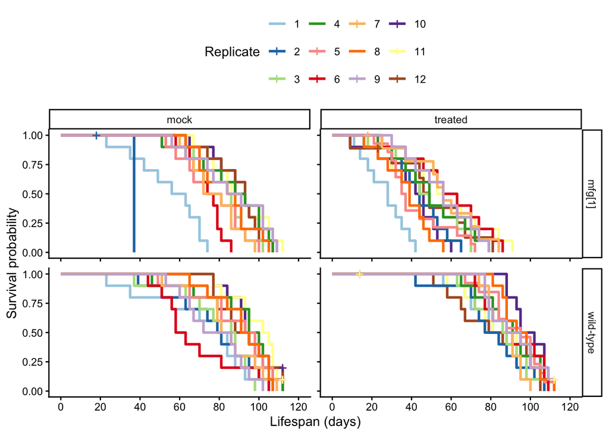

```r
# replicate as a factor → discrete colours + a clean legend
levels <- as.character(sort(unique(as.integer(as.character(survdata$replicate)))))
survdata$replicate <- factor(survdata$replicate, levels = levels)

fit <- survfit(Surv(time = day, event = event) ~ replicate, data = survdata)

g <- ggsurvplot_facet(
  fit, survdata,
  facet.by      = c(var1, var2),   # one panel per stratum (var1/var2 are strings)
  axis.labels   = "all",
  color         = "replicate",     # colour each replicate to spot outliers
  conf.int      = FALSE,           # keep curves clean, like the base-R version
  censor        = TRUE,            # + censoring marks
  break.time.by = 20,              # tick spacing, echoing axis(seq(10,90,20))
  xlab          = "Lifespan (days)",
  ylab          = "Survival probability",
  short.panel.labs = TRUE,         # panel strips show just the level
  ggtheme       = theme_classic()  # minimal, base-R-like: axis lines, no grid
) +
  # to control the order of colours and replicate number
  scale_colour_manual(
    values = brewer.pal(12, "Paired"),
    name   = "Replicate",
    limits = levels,
    breaks = levels
  ) +
  # to plot internal XY axes
 facet_grid(
  rows = vars(.data[[var1]]),
  cols = vars(.data[[var2]]),
  axes        = "all",
  axis.labels = "margins"
)

g
```

From this, we might want to remove replicate #2 of the *mfg<sup>1</sup>*, mock stratum, as there is full mortality beforre day 40. However, this is likely due to a large amount of censoring at around day 20, followed by the death of one or two individuals left in the tube (see Jupyter notebook #3, section 3C). This will likely have no impact on the final result, but we might just as well eliminate this replicate:

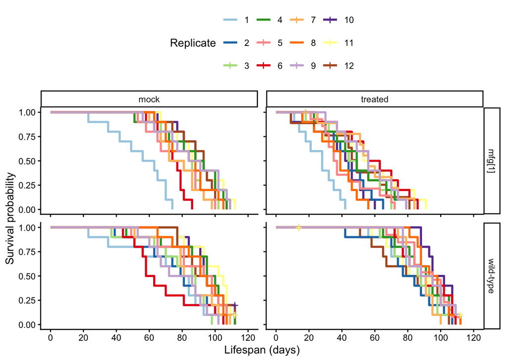

```r
survdata_filt <- survdata %>%
  filter_out(.data[[var1]]=='mfg[1]' & .data[[var2]]=='mock' & replicate==2)

fit <- survfit(Surv(time = day, event = event) ~ replicate, data = survdata_filt)

g <- ggsurvplot_facet(
  fit, survdata_filt,
  facet.by      = c(var1, var2),   # one panel per stratum (var1/var2 are strings)
  axis.labels   = "all",
  color         = "replicate",     # colour each replicate to spot outliers
  conf.int      = FALSE,           # keep curves clean, like the base-R version
  censor        = TRUE,            # + censoring marks
  break.time.by = 20,              # tick spacing, echoing axis(seq(10,90,20))
  xlab          = "Lifespan (days)",
  ylab          = "Survival probability",
  short.panel.labs = TRUE,         # panel strips show just the level
  ggtheme       = theme_classic()  # minimal, base-R-like: axis lines, no grid
) +
  scale_colour_manual(
    values = brewer.pal(12, "Paired"),
    name   = "Replicate",
    limits = levels,
    breaks = levels
  ) +
 facet_grid(
  rows = vars(.data[[var1]]),
  cols = vars(.data[[var2]]),
  axes        = "all",
  axis.labels = "margins"
)

g
```

While replicates #1 for both treatments in *mfg<sup>1</sup>* individuals seem to be outliers, they are not fundamentally different and we will keep them.

## 4C. Effect on survival of genotype, treatment

### Basic Kaplan-Meier plot with log-rank testing

We want now to plot genotype and treatment in two colourblind-friendly hues (i.e. blue and orange) with each level on different lightness/linetype. We can choose colours from the `RColorBrewer` palettes:

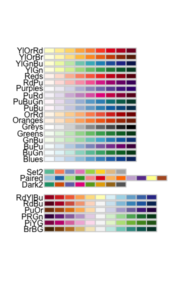

I will use colour #2 from Set2 as my orange and colour #2 from Paired as my blue, for the genotypes, and I will use shading and linetype to distinguish treatments:

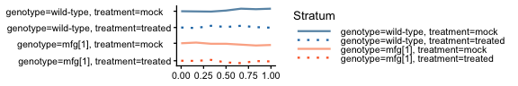

```r
# to keep the code generic, instead of writing the formula as
# Surv(day, event) ~ genotype + treatment
# we can use `glue`:
gluedformula <- as.formula(glue("Surv(day, event) ~ {var1} + {var2}"))
# this way the code could run with more than just the example data
fit <- surv_fit(formula = gluedformula,
               data = survdata_filt)
S <- surv_two_var_aes(fit, survdata_filt,
                      hue   = var1, # genotypes distinguished by distinct colours
                      palette = c('Set2', 'Paired'), # selection of Brewer colours
                      idx = c(2,2),                  # by colour number within palette
                      hue_direction = "cold2hot", # order of colours
                      shade = var2, # treatments distinguished by saturation and linetype
                      darkening=TRUE)

p <- preview_aes(S, n_points=7)
p + theme(legend.key.height = unit(0.02, "cm"))
```

These combinations seem easy to discriminate, so we can now plot the 4 survival curves:

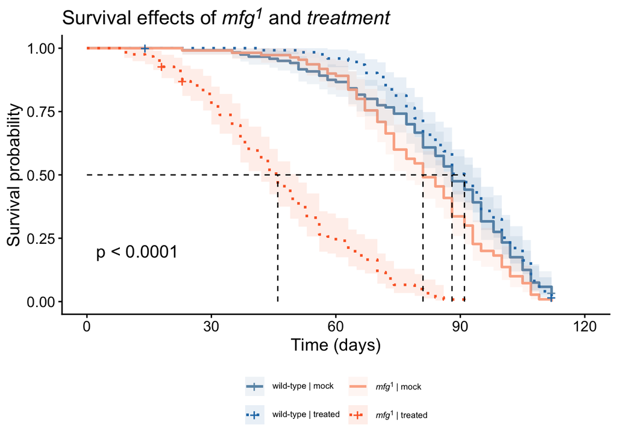

```r
# specific for the example dataset >>>
subs <- c("mfg[1]" = "_mfg_<sup>1</sup>")
legendlabs <- strata_labels(fit, delim=' | ', subs = subs)
title <- 'Survival effects of _mfg^1^_ and _treatment_' # specific for the example dataset
# <<< specific for the example dataset

g <- ggsurvplot(fit, survdata_filt,
                pval = TRUE,                       # adds pval
                conf.int = TRUE,                   # adds 95% confidence interval
                conf.int.alpha = 0.1,              # makes it more transparent
                surv.median.line = "hv",           # adds median points
                palette  = unname(S$colours),
                linetype = unname(S$linetypes),
                xlab = "Time (days)",              # remove x axis label
                ylab = "Survival probability",     # y axis label
                font.legend = c(7),                # legend size
                legend = "bottom",                 # legend position

                title = title,           # comment or change for your own data
                legend.labs = legendlabs # comment or change for your own data
)

g$plot <- g$plot + # specific layering for ggsurvplot
  guides(colour = guide_legend(ncol = 2), linetype = guide_legend(ncol = 2)) +
  theme(plot.title = element_markdown(),
        legend.text = element_markdown(),
        legend.title = element_blank())
g
```

```r
ggsave(
  'km_basic.pdf',
  plot = get_last_plot(),
  width = 8,
  height = 5,
  units ="cm",
  dpi = 300)
```

From this, it is clear that the treatment seems to have no effect, or very little (and positive) on the wild-types, but a very strong effect on the *mfg<sup>1</sup>* mutants. However, the untreated *mfg<sup>1</sup>* mutants also seem to have a higher mortality than wild-types. The compound effect of mutation and treatment does not seem additive, but this analysis cannot tell us whether there is an interaction between genotype and treatment (i.e. whether the treatment is detrimental *specifically* for *mfg<sup>1</sup>* flies).

The p-value indicated in the figure is from a log-rank test, which only tells us whether, of the 4 survival curves, at least one is significantly different. If we wanted more detail (e.g. are untreated mutants less longevous than untreated controls?), we would need to do paired log-rank tests.

However, if the assumptions of the Cox Proportional Hazards model were respected, this modelling would be far more informative, as we could ask for variable interactions.

### Cox Proportional Hazards modelling

To test whether our data respect the assumption of proportional hazards, first we need to build the model itself, so we might just as well evaluate the model first and check after whether it is solid.

For this, we simply change the generic modelling produced by `survival::survfit` or `survminer::surv_fit` for `survival::coxph`:

```r
gluedformula <- as.formula(glue("Surv(day, event) ~ {var1} * {var2}"))
# `~ var1 * var2` expands to `~ var1 + var2 + var1:var2`
phfit <- coxph(formula = gluedformula,
               data = survdata_filt)
```

From this, we can obtain the *Hazard Ratios* (HR) for each of the significant conditions and their p-values:

```r
tbl_regression(phfit,
               exponentiate = TRUE,
               pvalue_fun = ~ format.pval(.x, digits = 1, eps = 1e-16)
) %>% bold_p()
```

| **Characteristic** | **HR** | **95% CI** | **p-value** |
| --- | --- | --- | --- |
| genotype |  |  |  |
| wild-type | — | — |  |
| mfg[1] | 1.44 | 1.11, 1.87 | 0.007 |
| treatment |  |  |  |
| mock | — | — |  |
| treated | 0.94 | 0.72, 1.21 | 0.607 |
| genotype * treatment |  |  |  |
| mfg[1] * treated | 7.24 | 4.92, 10.7 | <1e-16 |

Abbreviations: CI = Confidence Interval, HR = Hazard Ratio

We can also obtain explicitly the median survival for each experimental stratum:

```r
medians <- summary(fit)$table[, "median"]
medians <- data.frame(names = names(medians),
                      medians = unname(medians))
medians <- medians %>%
  mutate(conditions = str_replace_all(names, "[^=,]+=", "")) %>%
  mutate(conditions = str_replace(conditions, ",", " | ")) %>%
  mutate(conditions = trimws(conditions)) %>%
  select(!names)
kbl(medians) %>%
  kable_styling(full_width = FALSE) %>%
  column_spec(1:ncol(medians), width = "10em")
```

| medians | conditions |
| --- | --- |
| 88 | wild-type \| mock |
| 91 | wild-type \| treated |
| 81 | mfg[1] \| mock |
| 46 | mfg[1] \| treated |

All this confirms that:

The hazard ratio is not as intuitive as the median lifespan as a measure of the strength of the effect, but it is far more precise. Each condition’s hazard is like the decay rate of a radioactive isotope — the instantaneous *rate* at which survivors are “lost” — except that an isotope’s decay rate is constant, but death rates (mortality) tend to increase with age in most organisms, and *Drosophila* is no exception. So, the ‘half-life’ of a fly is reduced with age. The hazard ratio is simply how many times faster one condition decays than the other, and the model assumes that multiple stays constant across the lifespan (the *proportional hazards* assumption) even as the underlying rate (for the reference condition) climbs (in whichever temporal pattern).

In any case before continuing we need to check the model assumptions.

### Test for proportional hazards

The Schoenfeld residuals test is the diagnostic tool to assess whether the proportional hazards assumption is respected:

```r
model_zph<-cox.zph(phfit)
model_zph$table %>%
  kbl(digits = c(2, 0, 3)) %>%
  kable_styling(full_width = FALSE) %>%
  column_spec(1, width = "10em") %>%
  column_spec(2:4, width = "8em")
```

|  | chisq | df | p |
| --- | --- | --- | --- |
| genotype | 3.09 | 1 | 0.079 |
| treatment | 0.07 | 1 | 0.797 |
| genotype:treatment | 13.94 | 1 | 0.000 |
| GLOBAL | 17.24 | 3 | 0.001 |

We can have a graphical inspection of why this may be the case looking at the Schoenfeld residuals plots:

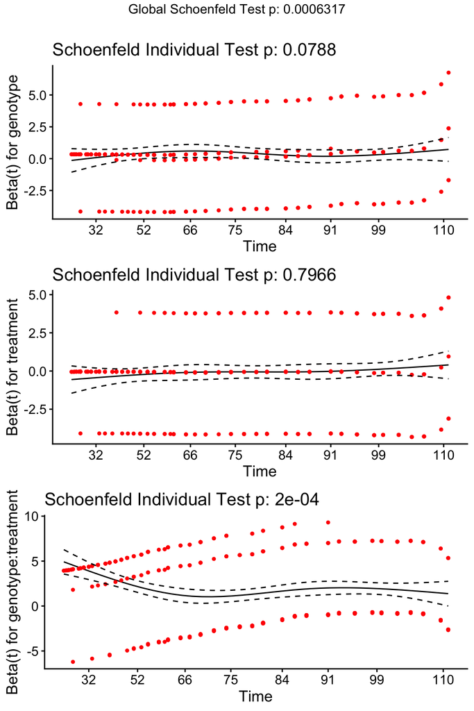

```r
ggcoxzph(model_zph)
```

These plots show how the residuals in the interaction term are not following the expectation. This does not mean that the conclusions from the CoxPH model are invalid - the fact that there is a real interaction between genotype and treatment can be seen by eye - but the interpretation of the hazards ratio, for instance, needs to be taken as a timed average rather than a constant.

We can make further diagnostics by detecting outliers:

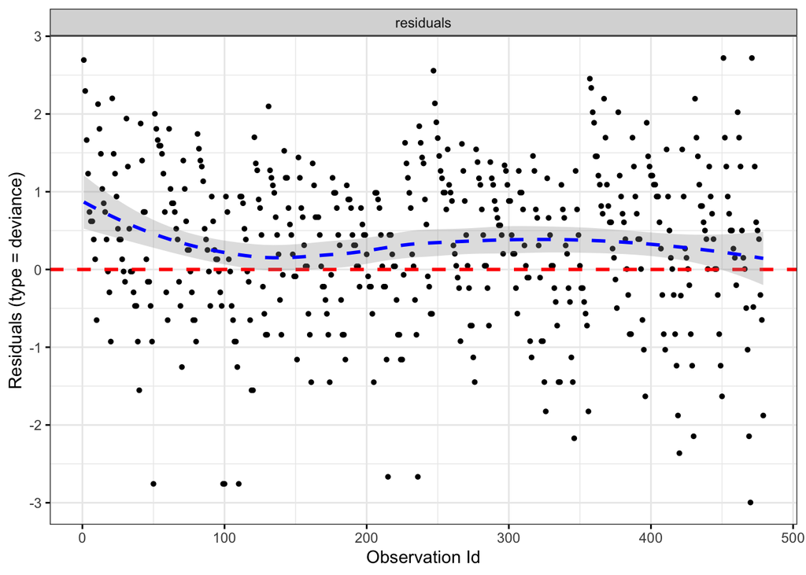

```r
ggcoxdiagnostics(phfit, type = 'deviance', linear.predictions = FALSE)
```

Here, we would expect to see a symmetric distribution of deviations around zero. There seems to be more weight over zero across observations, however there are no distant outliers.

The Martingale plot helps evaluating the linear relationship between the considered variables and the hazard ratios:

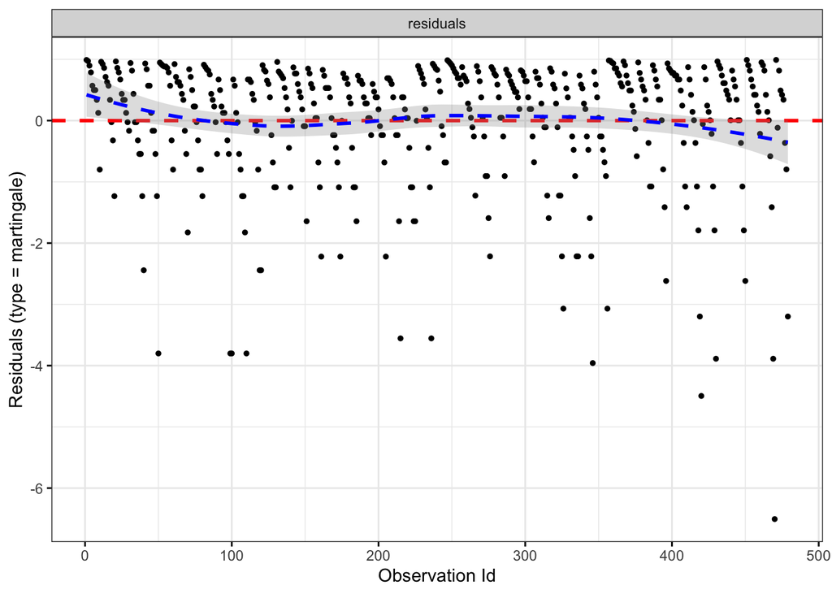

```r
ggcoxdiagnostics(phfit, linear.predictions = FALSE)
```

Each experiment may require more or less sophisticated analysis depending on the experimental design and how the data is distributed.

| END |
| --- |